# learning

- def of learning: a computer program is said to learn from experience $E$ if its performance at tasks T measured by P **improves** with experience E
- E: a set of data
- T: hard code in algo
- P: a loss function, optimized w.r.t training data or data we know answer

# NN is highly parameterized model

- (artificial) neural networks (ANN, NN) is parametric regression model (collections of individual neurons/nodes that multiple input by weights and add biases) with a ristricted type of non-linearity
- NN are highly **parameterized**, so it's very flexible and can approximate any **continuous** functions given enough size
- the more number of params, the more fitness of model
- creative design of **architecture, objective function, optimization algorithms and regularization, data augmentation** admits many practical applications across domains

## why go deep?

the deeper the NN

- higher complexity of learned function
  - a NN with a single layer perceptron can only handle linear separability
  - a NN with multiple layers can learn different functions in each layer: shallow layers extract more detailed features, deeper layers extract more abstract features
- better representation learning
  - how data is represented is important for tasks, a NN can learn a good representation of data can perform task very easy
  - a NN with multiple layers can learn different representation of data in each layer: first several layers preserve more info of input while last several layers preserve more info of output

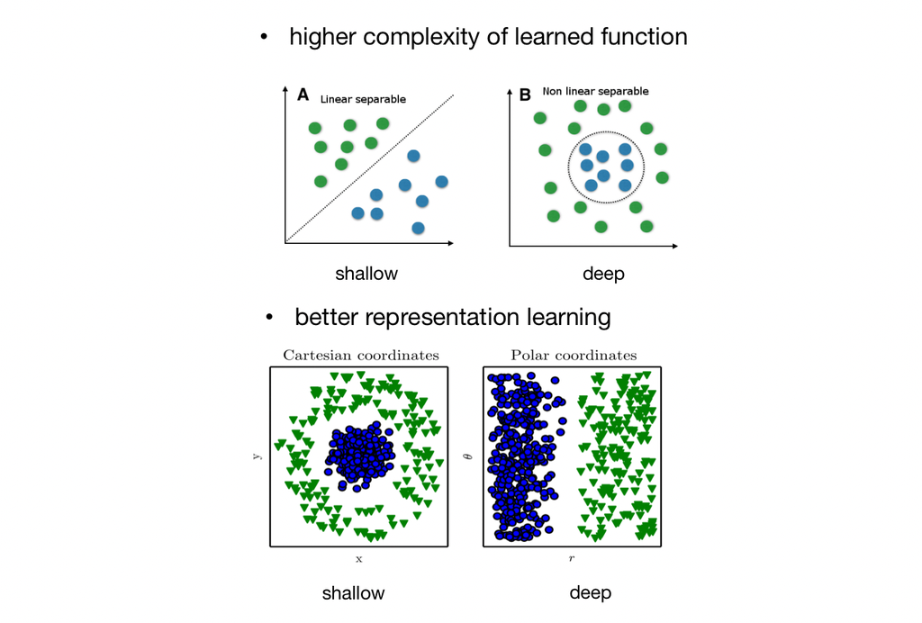

# Key Components of DL

- data: input and output data used for training and testing the model.

  distribution of data in training/validation/test set

  amount of data, data augmentation
- architecture: choice of layers, depth, width, activation, connectivity
- objective function: measures how well the model learned
- optimization algorithm: adjust model’s parameters during training to optimize the objective function.

  learning rate, number of epochs, initialization
- regularization: Techniques used to reduce overfitting and improve generalization
- metrics: evaluate model performance on test data

## objective function

- objective function $J: \mathcal{Y} \times \mathcal{Y} \rightarrow \mathbb{R}$
- objective function can be loss function plus explicit regularization term/penalty
- loss function and penalty has many choices, the only criteriais **differentiable**

## optimization

- optimization = learning = loss minimization
- a convex loss function can be solved by **differentiation**, have an analytical solution

  guaranteed to reach global minimum where **derivative = 0**
- most of ML and NN problems have non-convex loss function,

  use gradient descent to reach a good-enough **local minimum**